# Assignment 1: Neural Networks (IMDB - Fast Hyperparameter Experiments)

Jaipreet Kaur

## 1 Purpose (fast version)

This notebook **runs faster** by doing a focused set of experiments that still addresses every assignment requirement:

1. **Hidden layers:** compare 1 vs 2 (baseline) vs 3
2. **Hidden units:** compare 32 vs 64 (baseline) vs 128
3. **Loss:** compare `mse` vs `binary_crossentropy`
4. **Activation:** compare `tanh` vs `relu`
5. **Technique:** compare baseline vs **Dropout + L2 + Early stopping**

Instead of a full grid, we use a **one-factor-at-a-time** experiment plan (about 8 model runs total).

## 2 1. Environment setup (required for knitting)

```r
options(repos = c(CRAN = "https://cran.rstudio.com/"))

needed <- c("tensorflow","reticulate","dplyr","tidyr","ggplot2","purrr","knitr")
to_install <- needed[!vapply(needed, requireNamespace, logical(1), quietly = TRUE)]
if (length(to_install) > 0) install.packages(to_install)

library(tensorflow)
library(dplyr)
library(tidyr)
library(ggplot2)
library(purrr)
set.seed(123)
tensorflow::tf$random$set_seed(123L)
```

## 3 2. Load & prepare IMDB data (via Python)

```r
max_words <- 10000L

library(reticulate)

py_run_string("
import numpy as np
from tensorflow.keras.datasets import imdb

max_words = 10000
(train_seq, y_train), (test_seq, y_test) = imdb.load_data(num_words=max_words)
")

train_seq <- py$train_seq
y_train   <- as.numeric(py$y_train)
test_seq  <- py$test_seq
y_test    <- as.numeric(py$y_test)

vectorize_sequences <- function(sequences, dimension = max_words) {
  n <- length(sequences)
  results <- matrix(0, nrow = n, ncol = dimension)
  for (i in seq_len(n)) {
    idx <- sequences[[i]]
    idx <- idx[idx > 0 & idx <= dimension]
    results[i, idx] <- 1
  }
  results
}

x_train <- vectorize_sequences(train_seq, max_words)
x_test  <- vectorize_sequences(test_seq,  max_words)

# Validation split (10,000 samples)
val_n <- 10000
x_val <- x_train[1:val_n, ]
partial_x_train <- x_train[(val_n + 1):nrow(x_train), ]
y_val <- y_train[1:val_n]
partial_y_train <- y_train[(val_n + 1):length(y_train)]

# Make y arrays 2D for Keras adapter compatibility
y_val_m <- as.matrix(y_val)
y_train_m <- as.matrix(partial_y_train)
y_test_m <- as.matrix(y_test)

c(train = nrow(partial_x_train), val = nrow(x_val), test = nrow(x_test))
```

```
## train   val  test
## 15000 10000 25000
```

## 4 3. Model builder (tf$keras)

```r
tf <- tensorflow::tf

build_model <- function(
  n_hidden_layers = 2L,
  units = 64L,
  activation = "relu",
  loss = "binary_crossentropy",
  dropout_rate = 0,
  l2_lambda = 0
) {
  regularizer <- if (l2_lambda > 0) tf$keras$regularizers$l2(l2_lambda) else NULL

  model <- tf$keras$models$Sequential()

  model$add(tf$keras$layers$Dense(
    units = as.integer(units),
    activation = activation,
    input_shape = list(as.integer(max_words)),
    kernel_regularizer = regularizer
  ))

  if (dropout_rate > 0) model$add(tf$keras$layers$Dropout(rate = dropout_rate))

  if (n_hidden_layers > 1) {
    for (i in 2:as.integer(n_hidden_layers)) {
      model$add(tf$keras$layers$Dense(
        units = as.integer(units),
        activation = activation,
        kernel_regularizer = regularizer
      ))
      if (dropout_rate > 0) model$add(tf$keras$layers$Dropout(rate = dropout_rate))
    }
  }

  model$add(tf$keras$layers$Dense(units = 1L, activation = "sigmoid"))

  model$compile(
    optimizer = "rmsprop",
    loss = loss,
    metrics = list("accuracy")
  )

  model
}
```

## 5 4. Focused experiment plan (fast)

Baseline used in class: **2 layers, 64 units, relu, binary_crossentropy, no regularization**.

Then we change **one factor at a time** to satisfy each requirement.

```r
baseline <- list(
  name = "Baseline (2L,64,relu,BCE,no-reg)",
  n_hidden_layers = 2L, units = 64L, activation = "relu", loss = "binary_crossentropy",
  dropout_rate = 0, l2_lambda = 0
)

experiments <- list(
  baseline,
  list(name="1 Hidden Layer",  n_hidden_layers=1L, units=64L, activation="relu", loss="binary_crossentropy", dropout_rate=0,   l2_lambda=0),
  list(name="3 Hidden Layers", n_hidden_layers=3L, units=64L, activation="relu", loss="binary_crossentropy", dropout_rate=0,   l2_lambda=0),
  list(name="32 Units",        n_hidden_layers=2L, units=32L, activation="relu", loss="binary_crossentropy", dropout_rate=0,   l2_lambda=0),
  list(name="128 Units",       n_hidden_layers=2L, units=128L, activation="relu", loss="binary_crossentropy", dropout_rate=0,  l2_lambda=0),
  list(name="Loss = MSE",      n_hidden_layers=2L, units=64L, activation="relu", loss="mse",                 dropout_rate=0,   l2_lambda=0),
  list(name="Activation = tanh",n_hidden_layers=2L, units=64L, activation="tanh",loss="binary_crossentropy", dropout_rate=0,   l2_lambda=0),
  list(name="Technique: Dropout+L2", n_hidden_layers=2L, units=64L, activation="relu", loss="binary_crossentropy", dropout_rate=0.2, l2_lambda=0.001)
)

length(experiments)
```

```
## [1] 8
```

## 6 5. Run experiments (fast settings)

To run faster: - **epochs = 6** with **early stopping** - batch_size = 512

```r
run_one <- function(cfg) {
  model <- build_model(
    n_hidden_layers = cfg$n_hidden_layers,
    units = cfg$units,
    activation = cfg$activation,
    loss = cfg$loss,
    dropout_rate = cfg$dropout_rate,
    l2_lambda = cfg$l2_lambda
  )

  cb <- tf$keras$callbacks$EarlyStopping(
    monitor = "val_accuracy",
    patience = 1L,
    mode = "max",
    restore_best_weights = TRUE
  )

  history <- model$fit(
    x = partial_x_train,
    y = y_train_m,
    epochs = 6L,
    batch_size = 512L,
    validation_data = list(x_val, y_val_m),
    callbacks = list(cb),
    verbose = 0L
  )

  best_val_acc <- max(unlist(history$history$val_accuracy))

  eval <- model$evaluate(x_test, y_test_m, verbose = 0L)
  test_loss <- as.numeric(eval[[1]])
  test_acc  <- as.numeric(eval[[2]])

  tibble(
    experiment = cfg$name,
    n_hidden_layers = cfg$n_hidden_layers,
    units = cfg$units,
    activation = cfg$activation,
    loss = cfg$loss,
    dropout_rate = cfg$dropout_rate,
    l2_lambda = cfg$l2_lambda,
    best_val_accuracy = best_val_acc,
    test_accuracy = test_acc,
    test_loss = test_loss
  )
}

results <- purrr::map_dfr(experiments, run_one)
results
```

```
## # A tibble: 8 × 10
##   experiment       n_hidden_layers units activation loss  dropout_rate l2_lambda
##   <chr>                      <int> <int> <chr>      <chr>        <dbl>     <dbl>
## 1 Baseline (2L,64…               2    64 relu       bina…          0       0
## 2 1 Hidden Layer                 1    64 relu       bina…          0       0
## 3 3 Hidden Layers                3    64 relu       bina…          0       0
## 4 32 Units                       2    32 relu       bina…          0       0
## 5 128 Units                      2   128 relu       bina…          0       0
## 6 Loss = MSE                     2    64 relu       mse            0       0
## 7 Activation = ta…               2    64 tanh       bina…          0       0
## 8 Technique: Drop…               2    64 relu       bina…          0.2     0.001
## # ℹ 3 more variables: best_val_accuracy <dbl>, test_accuracy <dbl>,
## #   test_loss <dbl>
```

## 7 6. Summary table (required)

```r
results_sorted <- results |> arrange(desc(best_val_accuracy), desc(test_accuracy))
knitr::kable(results_sorted, digits = 4)
```

| experiment | n_hidden_layers | units | activation | loss | dropout_rate | l2_lambda | best_val_accuracy | test_accuracy | test_loss |
| --- | --- | --- | --- | --- | --- | --- | --- | --- | --- |
| Activation = tanh | 2 | 64 | tanh | binary_crossentropy | 0.0 | 0.000 | 0.8906 | 0.8834 | 0.2869 |
| Baseline (2L,64,relu,BCE,no-reg) | 2 | 64 | relu | binary_crossentropy | 0.0 | 0.000 | 0.8883 | 0.8830 | 0.2907 |
| Loss = MSE | 2 | 64 | relu | mse | 0.0 | 0.000 | 0.8859 | 0.8833 | 0.0885 |
| 32 Units | 2 | 32 | relu | binary_crossentropy | 0.0 | 0.000 | 0.8846 | 0.8793 | 0.2979 |
| 1 Hidden Layer | 1 | 64 | relu | binary_crossentropy | 0.0 | 0.000 | 0.8755 | 0.8715 | 0.3638 |
| 3 Hidden Layers | 3 | 64 | relu | binary_crossentropy | 0.0 | 0.000 | 0.8677 | 0.8667 | 0.3514 |
| 128 Units | 2 | 128 | relu | binary_crossentropy | 0.0 | 0.000 | 0.8594 | 0.8590 | 0.3595 |
| Technique: Dropout+L2 | 2 | 64 | relu | binary_crossentropy | 0.2 | 0.001 | 0.8548 | 0.8510 | 0.5304 |

## 8 7. Graphs (required)

### 8.1 7.1 Validation accuracy by experiment

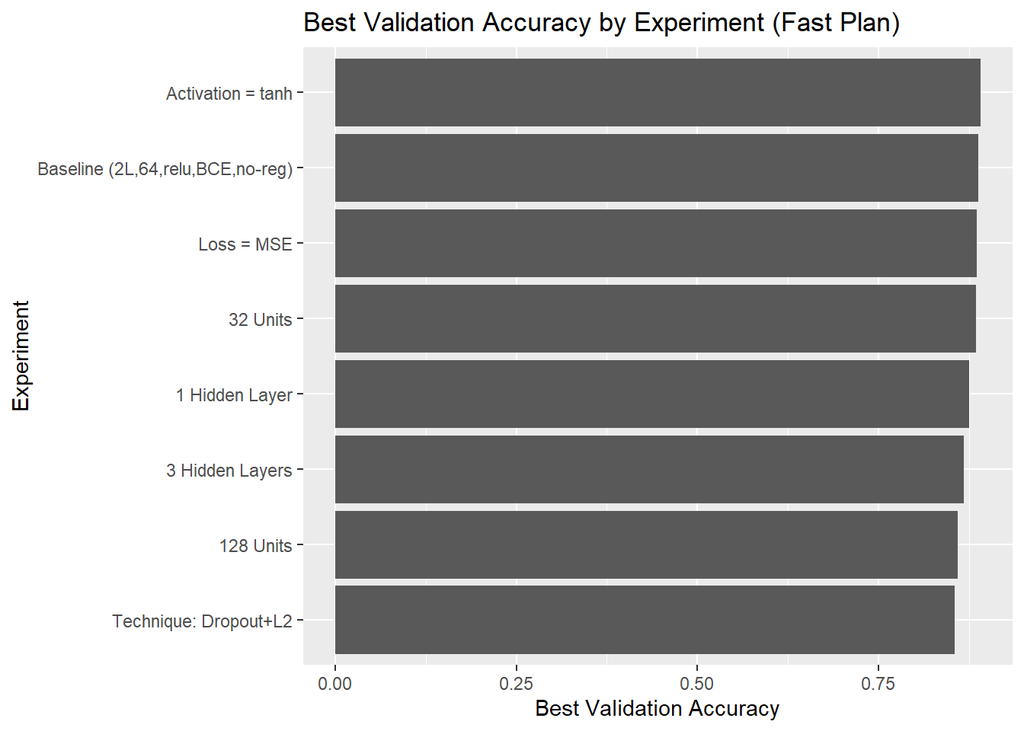

```r
ggplot(results_sorted, aes(x = reorder(experiment, best_val_accuracy), y = best_val_accuracy)) +
  geom_col() +
  coord_flip() +
  labs(
    title = "Best Validation Accuracy by Experiment (Fast Plan)",
    x = "Experiment",
    y = "Best Validation Accuracy"
  )
```

### 8.2 7.2 Test accuracy by experiment

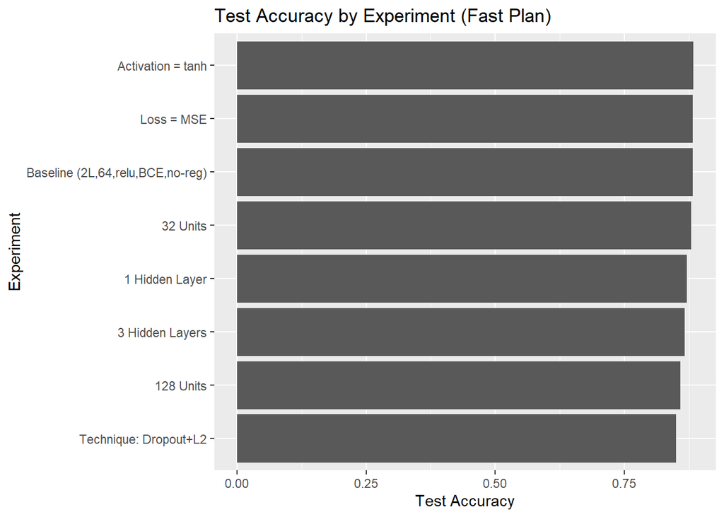

```r
ggplot(results_sorted, aes(x = reorder(experiment, test_accuracy), y = test_accuracy)) +
  geom_col() +
  coord_flip() +
  labs(
    title = "Test Accuracy by Experiment (Fast Plan)",
    x = "Experiment",
    y = "Test Accuracy"
  )
```

## 9 8. Final conclusion / story (required)

```r
best <- results_sorted |> slice(1)
best
```

```
## # A tibble: 1 × 10
##   experiment       n_hidden_layers units activation loss  dropout_rate l2_lambda
##   <chr>                      <int> <int> <chr>      <chr>        <dbl>     <dbl>
## 1 Activation = ta…               2    64 tanh       bina…            0         0
## # ℹ 3 more variables: best_val_accuracy <dbl>, test_accuracy <dbl>,
## #   test_loss <dbl>
```

### 9.1 Conclusion

The final selected model is the experiment with the highest validation accuracy (and strong test accuracy), shown in the `best` row.

## 10 9. Export results (for GitHub)

```r
write.csv(results, "imdb_hyperparam_results_fast.csv", row.names = FALSE)
list.files(pattern = "imdb_hyperparam_results_fast.csv")
```

```
## [1] "imdb_hyperparam_results_fast.csv"
```